# Session 10 Solutions: Statistics and modeling

Kenneth Tay

Oct 24, 2019

**Note: There are often multiple ways to answer each question.**

1. Install and load the `caret` package. Also load the `ggplot2` and `dplyr` packages. Load the `Sacramento` dataset with `data(Sacramento)`. Plot a histogram of the house prices with 50 bins.

```r
library(caret)
```

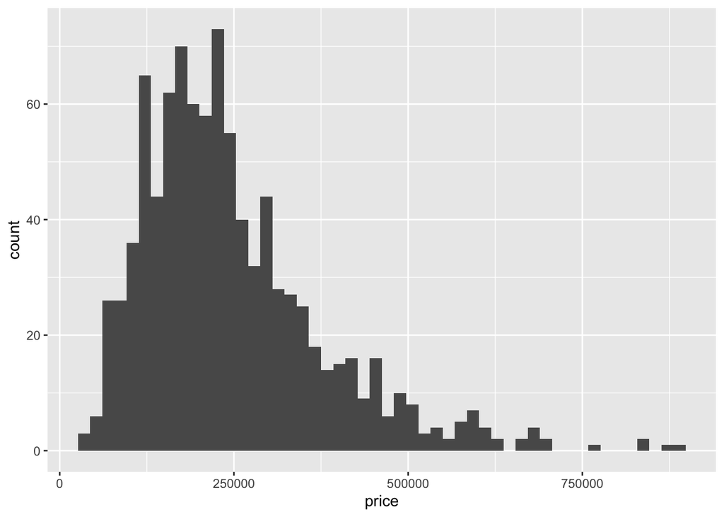

```r
library(ggplot2)
library(dplyr)
data(Sacramento)
ggplot(Sacramento, aes(x = price)) +
    geom_histogram(bins = 50)
```

2. Make a violin plot of `price` for each level of `type`. Overlay this with a scatterplot with the same `x` and `y` aesthetics, but define the `col` by `factor(beds)` and introduce jitter and alpha for the points. Make some observations.

There are many more residential homes compared to condos and multi-family homes. Conds seem to be the cheapest on average. Multi-family homes and residential homes seem to be a bit more expensive on average, but there is a lot more variance in residential home prices.

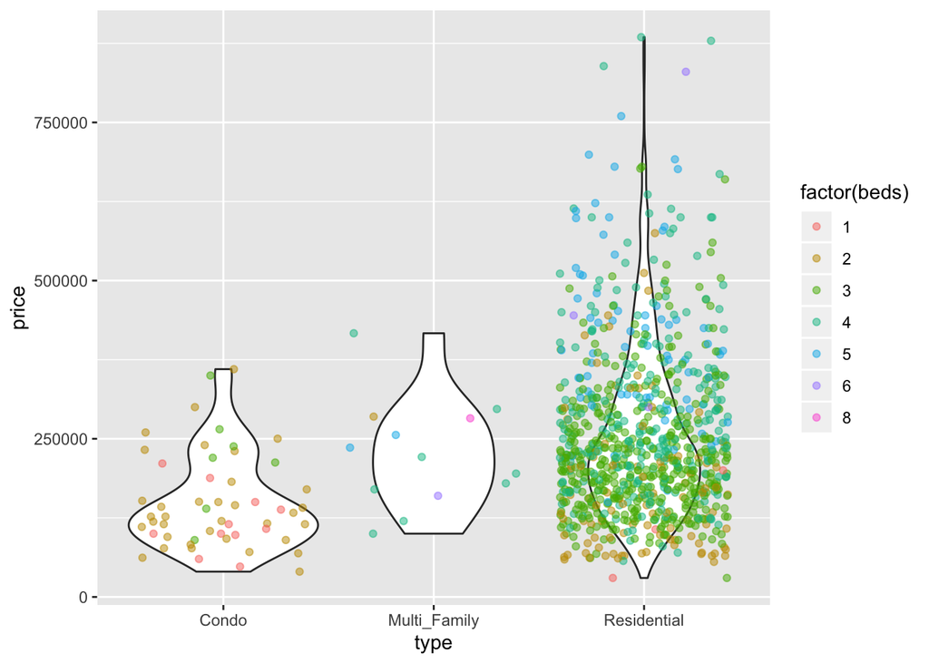

```r
ggplot(Sacramento, aes(x = type, y = price)) +
    geom_violin() +
    geom_point(aes(col = factor(beds)), position = "jitter", alpha = 0.5)
```

3. Do a $t$-test at the 95% level to see if the mean price for multi-family homes is statistically different from that for residential homes. (The test should be two-sided.)

The code below shows that the $p$-value is 0.26, which means that we don’t have enough evidence to reject the null hypothesis of the means being the same.

```r
mf_data <- Sacramento[Sacramento$type == "Multi_Family",]$price
rs_data <- Sacramento[Sacramento$type == "Residential",]$price
t.test(mf_data, rs_data)
```

```
##
##  Welch Two Sample t-test
##
## data:  mf_data and rs_data
## t = -1.1849, df = 12.884, p-value = 0.2574
## alternative hypothesis: true difference in means is not equal to 0
## 95 percent confidence interval:
##  -80384.82  23472.20
## sample estimates:
## mean of x mean of y
##  224534.7  252991.0
```

4. Instead of doing a $t$-test, do a Kolmogorov-Smirnov test at the 95% level to see if the distribution of multi-family homes is statistically different from that for residential homes. (Again, the test should be two-sided.)

The $p$-value is 0.61, which means that we don’t have enough evidence to reject the null hypothesis of the distributions being the same.

```r
ks.test(mf_data, rs_data)
```

```
##
##  Two-sample Kolmogorov-Smirnov test
##
## data:  mf_data and rs_data
## D = 0.21292, p-value = 0.607
## alternative hypothesis: two-sided
```

5. Make a boxplot of `price` for each level of `beds`. Make another boxplot of `price` for each level of `baths`. Do you see a trend? (Note: You will want to plot `factor(beds)` and `factor(baths)`, as plotting separate boxplots for different values of a numeric variable doesn’t work.)

The more baths or beds, the higher the price of the home.

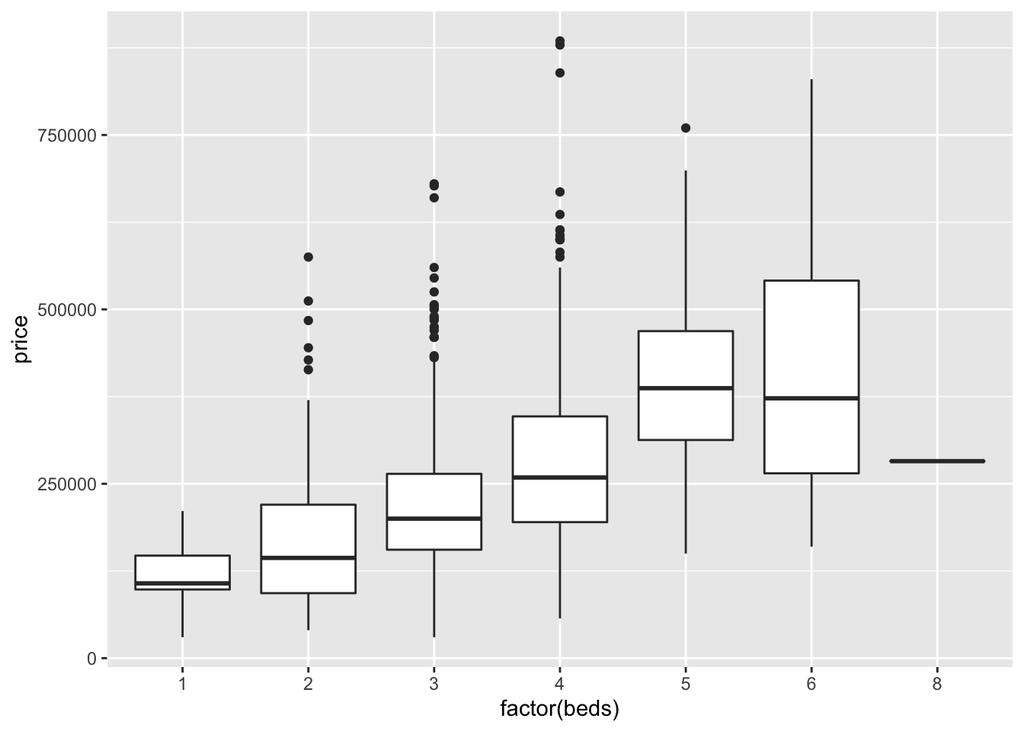

```r
ggplot(Sacramento, aes(x = factor(beds), y = price)) +
    geom_boxplot()
```

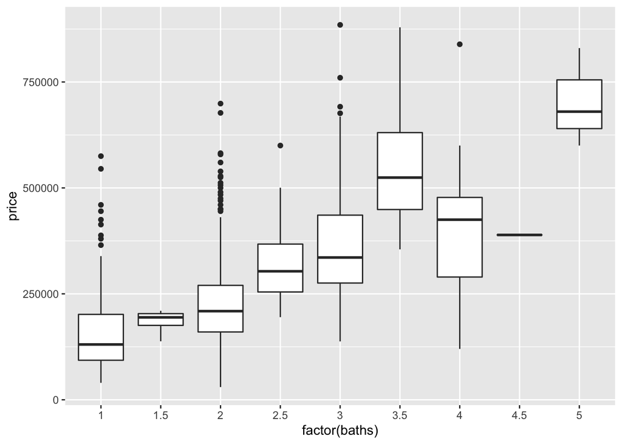

```r
ggplot(Sacramento, aes(x = factor(baths), y = price)) +
    geom_boxplot()
```

6. Fit an additive linear model of price against beds and baths with no interaction term. Interpret the coefficients of the model.

```r
fit <- lm(price ~ beds + baths, data = Sacramento)
summary(fit)
```

```
##
## Call:
## lm(formula = price ~ beds + baths, data = Sacramento)
##
## Residuals:
##     Min      1Q  Median      3Q     Max
## -315683  -67015  -20952   49048  540104
##
## Coefficients:
##             Estimate Std. Error t value Pr(>|t|)
## (Intercept)    -3679      13455  -0.273    0.785
## beds           22163       5203   4.260 2.26e-05 ***
## baths          86572       6394  13.540  < 2e-16 ***
## ---
## Signif. codes:  0 '***' 0.001 '**' 0.01 '*' 0.05 '.' 0.1 ' ' 1
##
## Residual standard error: 106300 on 929 degrees of freedom
## Multiple R-squared:  0.3442, Adjusted R-squared:  0.3428
## F-statistic: 243.8 on 2 and 929 DF,  p-value: < 2.2e-16
```

7. Instead of fitting an additive linear model of price against beds and baths with no interaction term (as in Question 6), fit a linear model as above but with an interaction term.

```r
fit <- lm(price ~ beds * baths, data = Sacramento)
summary(fit)
```

```
##
## Call:
## lm(formula = price ~ beds * baths, data = Sacramento)
##
## Residuals:
##     Min      1Q  Median      3Q     Max
## -333773  -67872  -21501   49655  540493
##
## Coefficients:
##             Estimate Std. Error t value Pr(>|t|)
## (Intercept)    28511      33606   0.848    0.396
## beds           12621      10507   1.201    0.230
## baths          70584      16578   4.258 2.27e-05 ***
## beds:baths      4463       4269   1.045    0.296
## ---
## Signif. codes:  0 '***' 0.001 '**' 0.01 '*' 0.05 '.' 0.1 ' ' 1
##
## Residual standard error: 106300 on 928 degrees of freedom
## Multiple R-squared:  0.3449, Adjusted R-squared:  0.3428
## F-statistic: 162.9 on 3 and 928 DF,  p-value: < 2.2e-16
```

8. Drop the columns `zip`, `latitude` and `longitude` from the dataset and save the result to `df`.

```r
df <- Sacramento %>% select(-zip, -latitude, -longitude)
```

9. We have many more columns of information in our dataset `df` that could help to predict price. Fit an additive linear model (with no interaction terms) of price against all other columns in `df`. (You will have to google around to find out how to do this!)

```r
fit <- lm(price ~ ., data = df)
summary(fit)
```

```
##
## Call:
## lm(formula = price ~ ., data = df)
##
## Residuals:
##     Min      1Q  Median      3Q     Max
## -245958  -43670   -9165   29768  401858
##
## Coefficients:
##                       Estimate Std. Error t value Pr(>|t|)
## (Intercept)          23330.328  17515.030   1.332 0.183195
## cityAUBURN          104667.280  34897.902   2.999 0.002782 **
## cityCAMERON_PARK     46072.765  26970.453   1.708 0.087935 .
## cityCARMICHAEL       85439.901  20345.056   4.200 2.94e-05 ***
## cityCITRUS_HEIGHTS    9665.403  17466.514   0.553 0.580151
## cityCOOL             93831.945  72605.464   1.292 0.196570
## cityDIAMOND_SPRINGS  30514.087  72616.662   0.420 0.674435
## cityEL_DORADO        49692.662  52187.963   0.952 0.341261
## cityEL_DORADO_HILLS 106484.720  20120.488   5.292 1.52e-07 ***
## cityELK_GROVE        10055.055  14184.769   0.709 0.478595
## cityELVERTA         -39524.939  37939.080  -1.042 0.297787
## cityFAIR_OAKS        75469.590  26936.592   2.802 0.005193 **
## cityFOLSOM          128168.817  21454.619   5.974 3.35e-09 ***
## cityFORESTHILL       18242.664  72625.771   0.251 0.801727
## cityGALT              6525.733  19985.347   0.327 0.744103
## cityGARDEN_VALLEY   157438.155  72835.709   2.162 0.030919 *
## cityGOLD_RIVER       82640.091  38107.512   2.169 0.030377 *
## cityGRANITE_BAY     302694.271  43417.787   6.972 6.10e-12 ***
## cityGREENWOOD         6146.228  73102.612   0.084 0.933014
## cityLINCOLN           3935.477  19873.987   0.198 0.843073
## cityLOOMIS          373492.368  52402.185   7.127 2.11e-12 ***
## cityMATHER          -52016.806  72700.467  -0.715 0.474491
## cityMEADOW_VISTA     62105.143  72769.260   0.853 0.393638
## cityNORTH_HIGHLANDS -26321.587  20156.623  -1.306 0.191940
## cityORANGEVALE       55858.065  24920.944   2.241 0.025245 *
## cityPENRYN          318538.623  72614.473   4.387 1.29e-05 ***
## cityPLACERVILLE     110008.457  25876.561   4.251 2.35e-05 ***
## cityPOLLOCK_PINES    46047.983  43199.542   1.066 0.286741
## cityRANCHO_CORDOVA   -7441.958  18438.617  -0.404 0.686599
## cityRANCHO_MURIETA  -30755.686  43311.085  -0.710 0.477821
## cityRIO_LINDA        -2378.510  23533.040  -0.101 0.919517
## cityROCKLIN          88921.249  21465.959   4.142 3.76e-05 ***
## cityROSEVILLE        62907.351  16279.920   3.864 0.000120 ***
## citySACRAMENTO        -629.545  12999.363  -0.048 0.961385
## cityWALNUT_GROVE    144896.791  72882.393   1.988 0.047108 *
## cityWEST_SACRAMENTO -17779.062  43314.173  -0.410 0.681562
## cityWILTON          185864.842  35372.181   5.255 1.86e-07 ***
## beds                -21735.472   4349.106  -4.998 6.99e-07 ***
## baths                 6576.108   5427.047   1.212 0.225938
## sqft                   131.523      6.359  20.684  < 2e-16 ***
## typeMulti_Family       987.870  23982.425   0.041 0.967153
## typeResidential      43262.632  11147.855   3.881 0.000112 ***
## ---
## Signif. codes:  0 '***' 0.001 '**' 0.01 '*' 0.05 '.' 0.1 ' ' 1
##
## Residual standard error: 71520 on 890 degrees of freedom
## Multiple R-squared:  0.7156, Adjusted R-squared:  0.7025
## F-statistic: 54.63 on 41 and 890 DF,  p-value: < 2.2e-16
```

10. Make a scatterplot of `price` against `sqft` and include the linear model fit on the plot (without standard error intervals). Make the title and axis labels informative. Fit the model as well and look at the R-squared value (how well `sqft` predicts `price`).

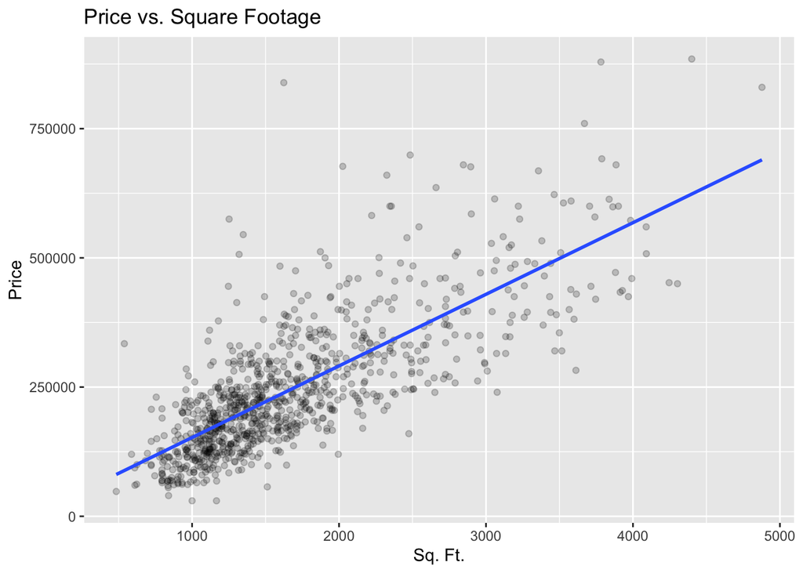

```r
ggplot(df, aes(x = sqft, y = price)) +
    geom_point(alpha = 0.2) +
    geom_smooth(method = "lm", se = FALSE) +
    labs(title = "Price vs. Square Footage", x = "Sq. Ft.", y = "Price")
```

```r
fit <- lm(price ~ sqft, data = df)
summary(fit)
```

```
##
## Call:
## lm(formula = price ~ sqft, data = df)
##
## Residuals:
##     Min      1Q  Median      3Q     Max
## -231889  -54717  -11822   38993  600141
##
## Coefficients:
##              Estimate Std. Error t value Pr(>|t|)
## (Intercept) 13859.393   6948.714   1.995   0.0464 *
## sqft          138.546      3.796  36.495   <2e-16 ***
## ---
## Signif. codes:  0 '***' 0.001 '**' 0.01 '*' 0.05 '.' 0.1 ' ' 1
##
## Residual standard error: 84130 on 930 degrees of freedom
## Multiple R-squared:  0.5888, Adjusted R-squared:  0.5884
## F-statistic:  1332 on 1 and 930 DF,  p-value: < 2.2e-16
```

11. Get the median house price for each city. Plot it on a map, with each city depicted by a point whose size is determined by the number of houses, and color determined by the median price.

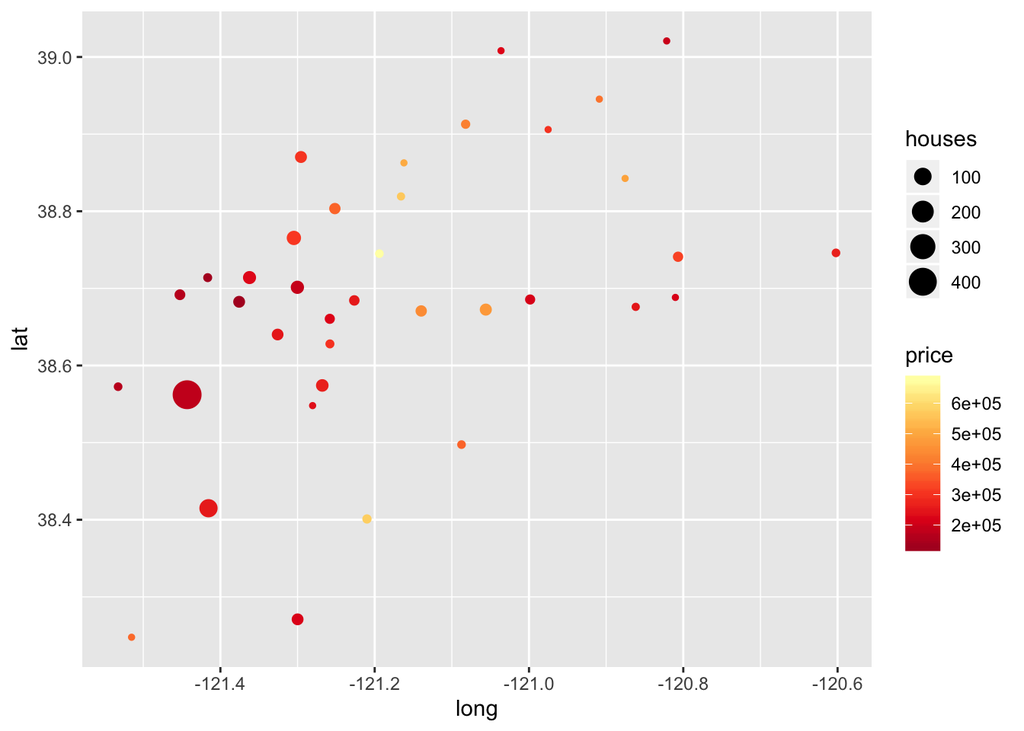

```r
city_df <- Sacramento %>%
    group_by(city) %>%
    summarize(houses = n(), price = median(price),
              lat = mean(latitude), long = mean(longitude))
ggplot(city_df, aes(x = long, y = lat)) +
    geom_point(aes(col = price, size = houses)) +
    scale_color_distiller(palette = "YlOrRd")
```

It would be even more informative if we could have the base map of Sacramento! Unfortunately, the main package used to do this (`ggmap`) seems a difficult to use at the moment. We make do with the county map from the `maps` package.

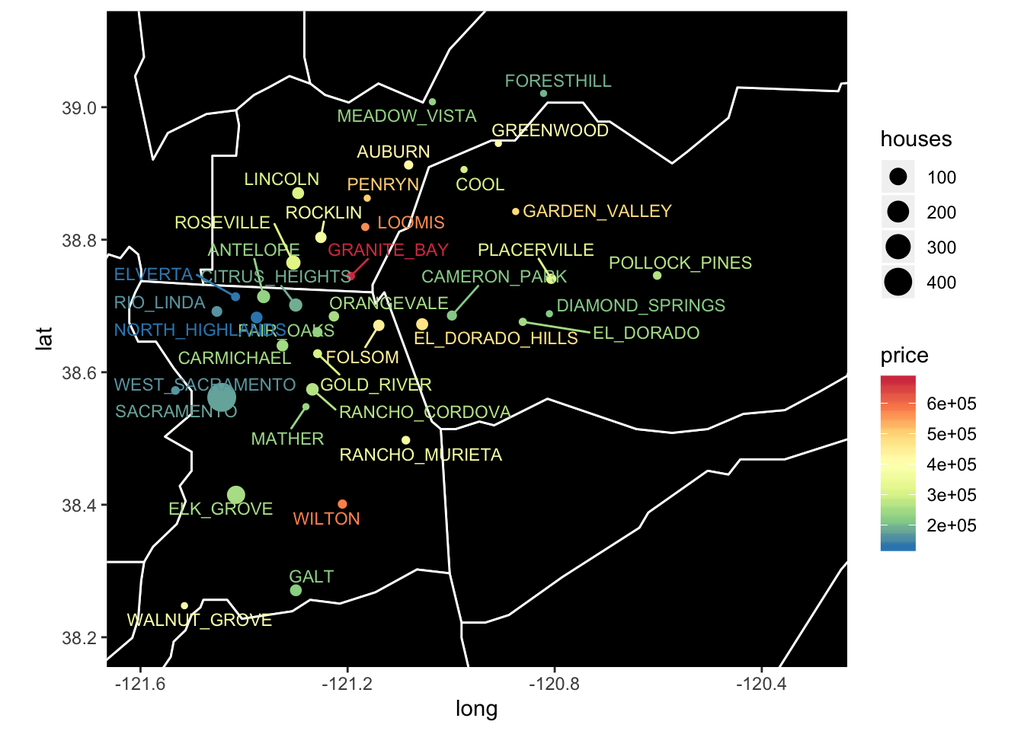

```r
library(ggrepel)
library(maps)
county_df <- map_data("county") %>%
    filter(region == "california")
ggplot(mapping = aes(x = long, y = lat)) +
    geom_polygon(data = county_df, mapping = aes(group = group),
                 fill = "black", col = "white") +
    geom_point(data = city_df, aes(col = price, size = houses)) +
    geom_text_repel(data = city_df, aes(label = city, col=price), size = 3) +
    scale_color_distiller(palette = "Spectral") +
    coord_quickmap(xlim = c(-121.6, -120.3), ylim = c(38.2, 39.1))
```